# Relatório de Coleta

2023-11-24

Esse relatório apresenta o progresso da coleta de dados do projeto “Pluralização da política externa ambiental brasileira”. Apresentamos aqui dados básicos sobre a versão mais atualizada do Banco de Dados de Atores e Eventos da Política Externa Ambiental Brasileira (1970-2018). O relatório traz, para fácil acesso, os números atualizados de eventos e participantes incluídos na base. O principal ponto do arquivo, porém, é apresentar os dados de sucesso/fracasso na coleta dos dados, que permitem avaliar eventuais vieses de seleção no banco.

```r
#working directory
knitr::opts_knit$set(root.dir = here::here())

## Carregando pacotes
library(tidyverse)
```

## Versão do banco

Relatório mais recente: “2023-11-24”

**Versão da planilha deleg**: 2023-11-23

**Versão da planilha orgs**: 2023-11-23

**Versão da planilha class**: 2022-06-29

**Versão da planilha eventos**: 2023-11-24

## Preparo do banco

Antes de apresentar os dados, é preciso construir o banco principal integrando os dados dos bancos parciais (eventos, delegações, indivíduos) no R. O script para isso será incluído aqui, mas rodado de forma silenciosa.

- Carregando as bases separadas

```r
## Importando os dados ------------
getlatest_file <- function(basefilename){
  list.files(pattern = paste0(basefilename, "-.+\\.csv"))
}

deleg <- read_delim(getlatest_file("deleg"),
                    ";", escape_double = FALSE,
                    col_types = cols(
                      #X1 = col_skip()
                      ),
                    #locale = locale(encoding = "ISO-8859-1"),
                    trim_ws = TRUE)

orgs <- read_delim(getlatest_file("orgs"),
                   ";", escape_double = FALSE,
                   col_types = cols(
                     #X1 = col_skip()
                     ),
                   #locale = locale(encoding = "ISO-8859-1"),
                   trim_ws = TRUE) %>% distinct()

class <- read_delim(getlatest_file("class"),
                   ";", escape_double = FALSE,
                   col_types = cols(
                     #X1 = col_skip()
                     ),
                   locale = locale(encoding = "ISO-8859-1"),
                   trim_ws = TRUE) %>% distinct()


eventos <- read_delim(getlatest_file("eventos"),
                      ";", escape_double = FALSE,
                      #locale = locale(encoding = "UTF-8"),
                      trim_ws = TRUE)
```

- Integrando as bases em uma

```r
# Criando deleg_completo (deleg+orgs+class) --------
orgs_classificado <- left_join(orgs, class) %>% select(-c(org_sujo, org_detalhe_sujo))
# N de rows aumenta, porque tem orgs que ficaram apenas na class e saíram da lista orgs (foram erros na padronização e corrigidos posteriormente)
# Teste (resultado deve ser tibble vazio): left_join(orgs, class, by = "id_org_unica") %>% filter(org_limpo.x != org_limpo.y)

deleg_completo <- deleg %>% select(-c(org, org_detalhe)) %>% left_join(orgs_classificado, by = "id_org_dupla")
# Limpando deleg_completo
deleg_completo <- deleg_completo %>% mutate(across(where(is.character), str_trim))

rm(deleg, orgs, class)
```

- Organizando a base de eventos

```r
# Limpando a base dos eventos --------

### Limpar e renomear colunas
eventos <- eventos %>% select(-c(`Código ONU`, Comentário,
                                 `Formato lista`,
                                 `Aberto?`, `Questões a atentar`,
                                 Corrigendum, Local)) %>% #retira colunas irrelevantes
  rename(#renomeia colunas
    conf = `Nome do evento`,
    conference = `Conf/Conv`,
    tema = `Regime/Tema`,
    data = Data,
    location = Locale,
    tipo_evento = `Tipo evento`,
    infMEA_list = `Lista MEA?`,
    coleta = `Coleta?`,
    proces = `Proces.?`,
    mainconf = `Principais convenções + gdes conf`
  )

eventos <- eventos %>% mutate(
  data = if_else(str_count(data)==4, #se falta o mês (só ano)
                 paste0(data, "-01"), #padroniza como janeiro
                 data)) %>%
  mutate(
    data = if_else(is.na(data)== F,
                   paste0(data, "-01"), #padroniza data no dia 1 do mês
                   data)
  ) %>% mutate(data = lubridate::ymd(data),
               ano = lubridate::year(lubridate::ymd(data)))

eventos <- eventos %>% mutate(across(where(is.character), str_trim))
```

## Descrição geral do banco

### Base total

A base inclui alguns eventos pré 1970 e pós 2018, mas a coleta não foi sistemática nesses períodos. Seguem abaixo os dados para as delegações e eventos **como um todo, isto é, sem filtros referentes a datas**:

**Número total de eventos identificados**: 592

**Número total de eventos coletados**:326

**Número total de organizações presentes nas delegações**: 751

**Número total de participações/nomes nas delegações** *(inclui repetições dos mesmos indivíduos)*: 8034

**Número de eventos com delegações brasileiras vazias** *(ie, para os quais foi obtida a lista de participantes, mas o Brasil não enviou delegação)*:15

### Base filtrada

A base inclui alguns eventos pré 1970 e pós 2018, mas a coleta não foi sistemática nesses períodos. Seguem abaixo os dados para as delegações e eventos considerando **apenas o período 1970-2018**:

```r
## filtrar a base
eventos <- eventos %>% filter(ano >= 1970 & ano <= 2018)
```

**Número total de eventos identificados**: 556

**Número total de eventos coletados**:303

**Número total de organizações presentes nas delegações**: 739

**Número total de participações/nomes nas delegações** *(inclui repetições dos mesmos indivíduos)*: 7766

**Número de eventos com delegações brasileiras vazias** *(ie, para os quais foi obtida a lista de participantes, mas o Brasil não enviou delegação)*:14

## Grau de sucesso da coleta: percentual de eventos incluídos na base

Os dados abaixo são apresentados levando em conta a base filtrada, isto é, **apenas os eventos no período 1970-2018**.

Eventos coletados/identificados ao longo do tempo

```r
###.... Linha: evolução eventos no tempo, dividido total e coletados ----
freqeventos_ano <- eventos %>% group_by(ano) %>% summarise(total = n())
freqeventos_ano_coletados <- eventos %>% filter(coleta == "Sim") %>%
  group_by(ano) %>% summarise(coletados = n())
freqeventos_ano <- left_join(freqeventos_ano, freqeventos_ano_coletados) %>%
  pivot_longer(cols = c(total, coletados), names_to = "Legenda")
## antes de montar os gráficos, é preciso incluir os anos faltantes na série como 0
freqeventos_ano <- complete(freqeventos_ano, ano = 1970:2018, nesting(Legenda),
                            fill = list(value = 0))
```

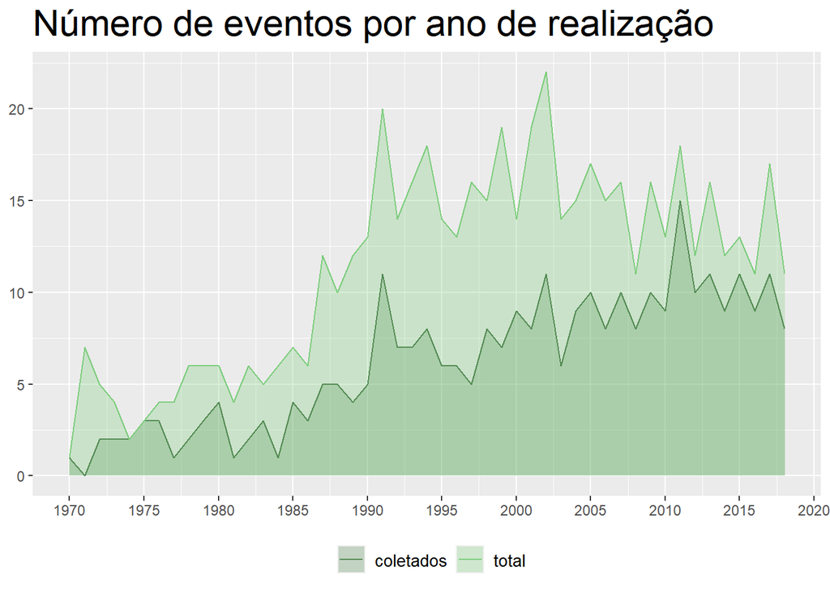

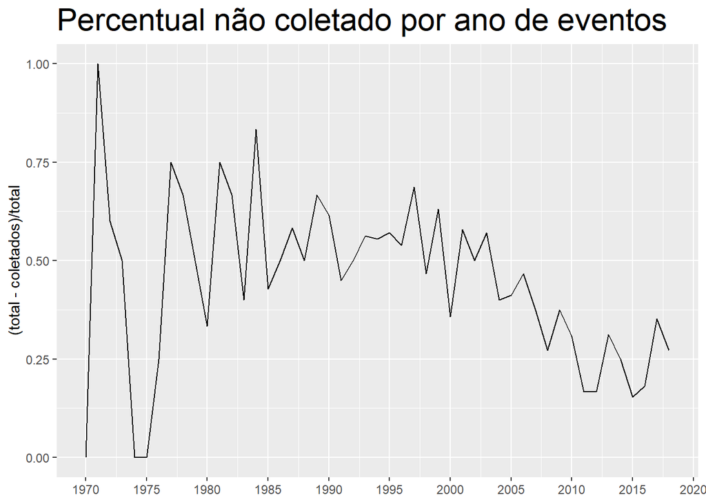

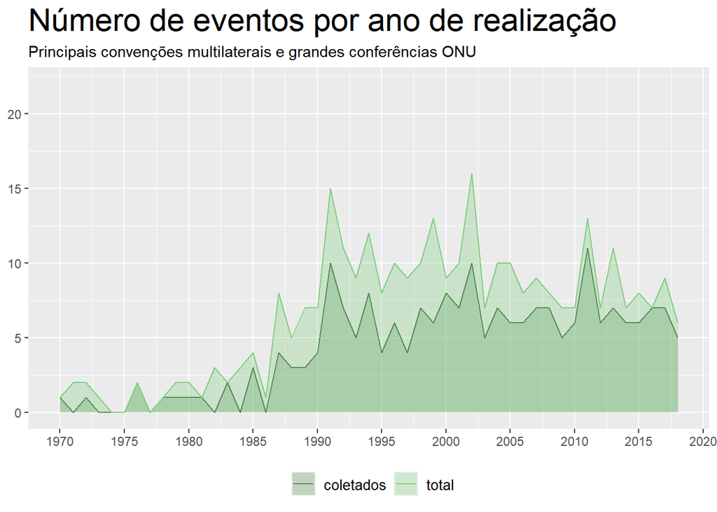

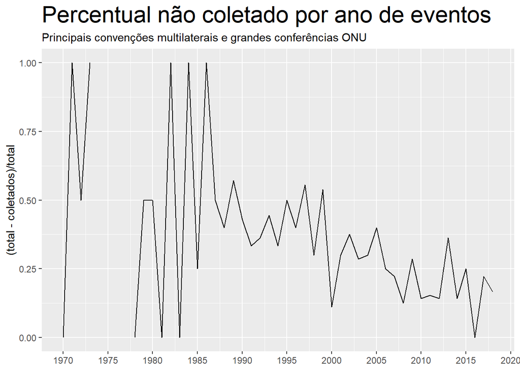

### Variação do sucesso da coleta por tema e tipo de evento

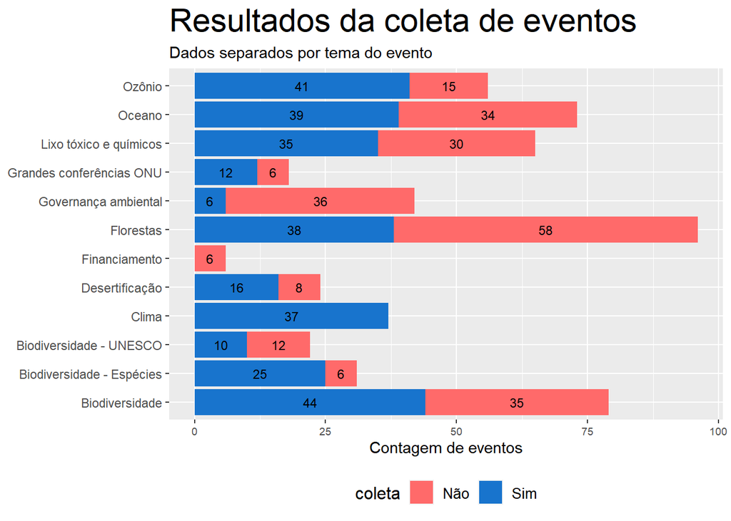

Notar que há muitos eventos incluídos na base referentes a florestas e biodiversidade. O maior número em Florestas é o ITTC (uns 59), o que também explica a coleta ruim (só consegui listas para 2010-2021 no ITTC). Os eventos provavelmente são pequenos e nao devem distorcer muito a base ou a centralidade do MMA, mas talvez sejam distorções relevantes para dados de ‘experiência’ dos atores. Biodiversidade é mais disperso nesse sentido - temos mau desempenho no ITPGRFA (pouco menos da metade coletado) e em Ramsar (nenhum). Valeria explorar um pouco mais, no futuro, os problemas em Oceano (acredito que seja uma situação parecida com Florestas) e em Lixo Tóxico e Químicos. Governança ambiental o fracasso é bastante uniforme, similar a Ramsar em biodiversidade.

Chequemos também a variação do sucesso da coleta por tema ao longo do tempo. Talvez não haja distorção muito grande no geral, mas pode haver viés relevante em alguns períodos.

```r
freqeventos_anotema <- eventos %>% group_by(ano, tema) %>% summarise(total = n())
```

[output not shown]

```r
freqeventos_anotema_coletados <- eventos %>% filter(coleta == "Sim") %>%
  group_by(ano, tema) %>% summarise(coletados = n())
```

[output not shown]

```r
freqeventos_anotema <- left_join(freqeventos_anotema, freqeventos_anotema_coletados) %>%
  pivot_longer(cols = c(total, coletados), names_to = "Legenda")
#completando os valores para todos os anos, temas, coletados ou não
freqeventos_anotema <- freqeventos_anotema %>% ungroup() %>%
  complete(ano = 1970:2018, nesting(tema, Legenda),
                           fill = list(value = 0))
```

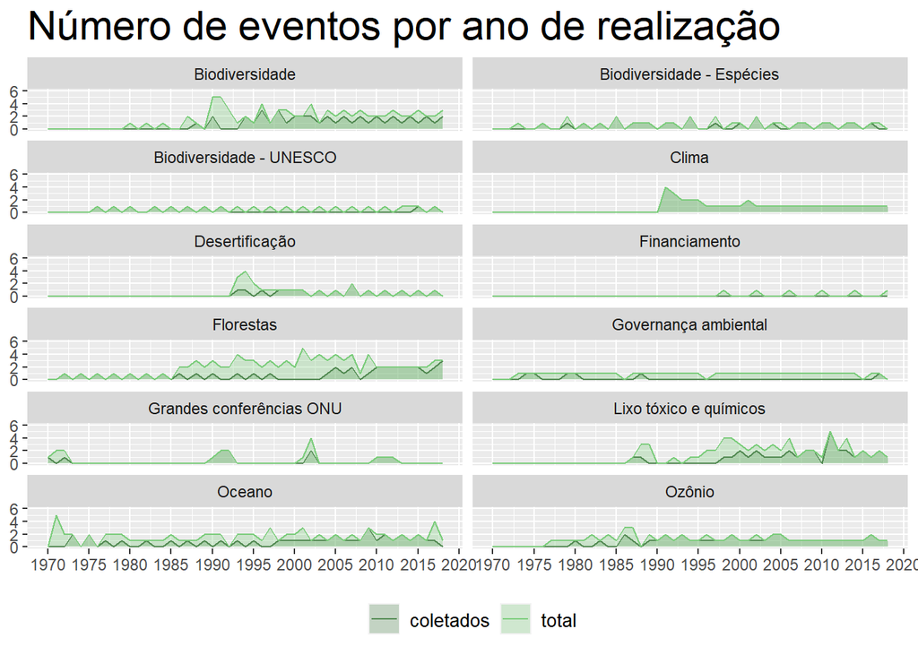

(talvez valesse a pena eu trocar as cores dos gráficos, pra deixar mais clara a diferença quando tem e quando não tem dados. notei que às vezes é difícil perceber que a coleta foi 100%, e usar cores com mais contraste facilitaria essa distinção.)

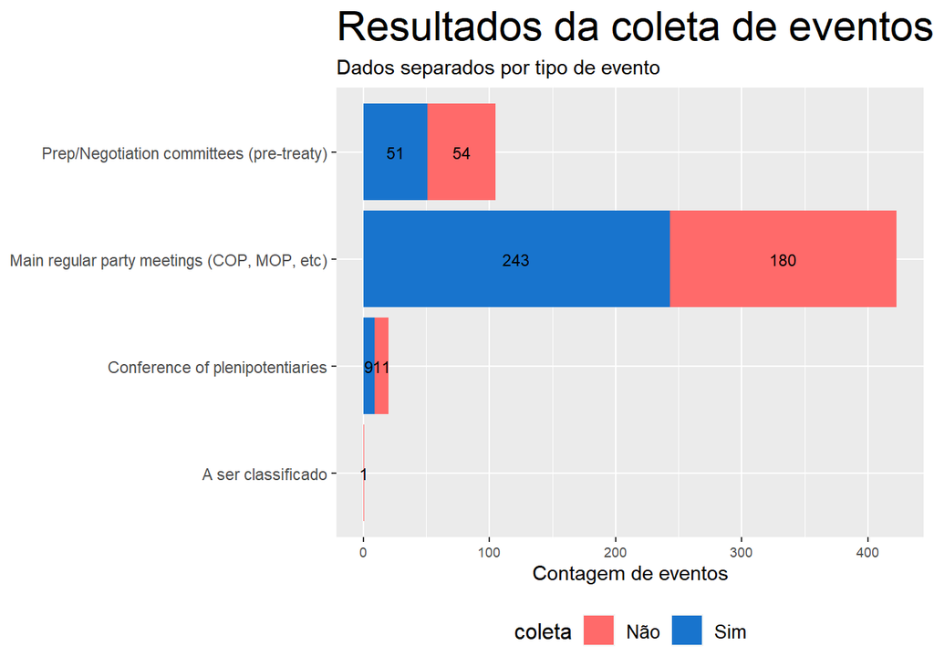

## Lista de conferências incluídas na base

[talvez valesse incluir, além de uma lista como a colocada de apêndice no Git, uma tabela dinâmica nos moldes da usada na minha planilha eventos do excel]